# Assignment2

Aijing

9/11/2020

# Load Dataset

```r
library(tidycensus)
library(tidyverse)
library(ggplot2)
```

```r
tract_data <- read_csv("tracts2018_suffolk.csv")
attach(tract_data)
```

The five variables I chose from Assignment 1 are:

1.Median income (continuous) : ‘med_income’

2.Percentage of of labour force using public transportation to workplace as percentage (continuous): ‘pct_publictrans’

3.Avg. Travel time to workplace for labor force (continuous): ‘avg_time_travel_work’

4.Majority race of the population (categorical) : ‘maj_race’

5.Whether the majority of the population is foreign born or not(categorical): ‘maj_foreign’

# Distribution of Continuous Variables

## Descriptive statistics

Here I calculate the sample mean, the sample standard deviation, the 95-percent confidence interval for the population mean, and the interquartile range of each continuous variable, and put them in a table.

```r
med_income_summary <- summary(med_incomeE)
med_income_sd <- sd(med_incomeE,na.rm = TRUE)
med_income_mean_int <- t.test(med_incomeE)

pct_publictrans_summary <- summary(pct_publictrans)
pct_publictrans_sd <- sd(pct_publictrans,na.rm = TRUE)
pct_publictrans_mean_int <- t.test(pct_publictrans)

avg_travel_time_summary <- summary(avg_travel_time)
avg_travel_time_sd <- sd(avg_travel_time,na.rm = TRUE)
avg_travel_time_mean_int <- t.test(avg_travel_time)
```

```r
summary_table <- tibble(
  Statistic = c("Sample mean",
                "Median",
                "Standard deviation",
                "Interquartile range",
                "Population mean (95% confidence)"),
  `Median Incomes (dolloars)` = c(prettyNum(med_income_summary["Mean"], digits=3),
                           med_income_summary["Median"],
                           prettyNum(med_income_sd, digits = 3),
                           paste(med_income_summary["1st Qu."],"to",
                                 med_income_summary["3rd Qu."]),
                           paste(prettyNum(med_income_mean_int$conf.int[1],
                                           digits=3), "to",
                                 prettyNum(med_income_mean_int$conf.int[2],
                                           digits=3))),

  `Pecentage of Labour Force Using Public Transportation for Commuting` =
                         c(paste(prettyNum(pct_publictrans_summary["Mean"]*100,
                                           digits=3),"%"),
                           paste(prettyNum(pct_publictrans_summary["Median"]*100,
                                           digits=3),"%"),
                           paste(prettyNum(pct_publictrans_sd*100, digits=3),"%"),
                           paste(prettyNum(pct_publictrans_summary["1st Qu."]*100,
                                           digits=3),
                                 "% to",
                                 prettyNum(pct_publictrans_summary["3rd Qu."]*100,
                                           digits=3), "%"),
                           paste(prettyNum(pct_publictrans_mean_int$conf.int[1]*100,
                                           digits=3), "% to",
                                 prettyNum(pct_publictrans_mean_int$conf.int[2]*100,
                                           digits=3), "%")),
  `Avg. Travel time to workplace (minitues)` =
    c(prettyNum(avg_travel_time_summary["Mean"], digits=3),
      prettyNum(avg_travel_time_summary["Median"]),
      prettyNum(avg_travel_time_sd, digits=3),
      paste(prettyNum(avg_travel_time_summary["1st Qu."], digits=3), "to",
            prettyNum(avg_travel_time_summary["3rd Qu."], digits=3)
            ),
      paste(prettyNum(avg_travel_time_mean_int$conf.int[1],digits=3),"to",
            prettyNum(avg_travel_time_mean_int$conf.int[2],digits=3)
            )
      )
)

knitr::kable(summary_table,
             caption = "Characteristics of census tracts in Suffolk County")
```

Characteristics of census tracts in Suffolk County

| Statistic | Median Incomes (dolloars) | Pecentage of Labour Force Using Public Transportation for Commuting | Avg. Travel time to workplace (minitues) |
| --- | --- | --- | --- |
| Sample mean | 36782 | 29.6 % | 27.1 |
| Median | 31006 | 28.4 % | 27.58417 |
| Standard deviation | 19382 | 10.5 % | 4.93 |
| Interquartile range | 23461 to 48534 | 22.1 % to 35.6 % | 23.9 to 30.3 |
| Population mean (95% confidence) | 34030 to 39533 | 28.1 % to 31.1 % | 26.4 to 27.8 |

## Histogram

### Median Income Histogram

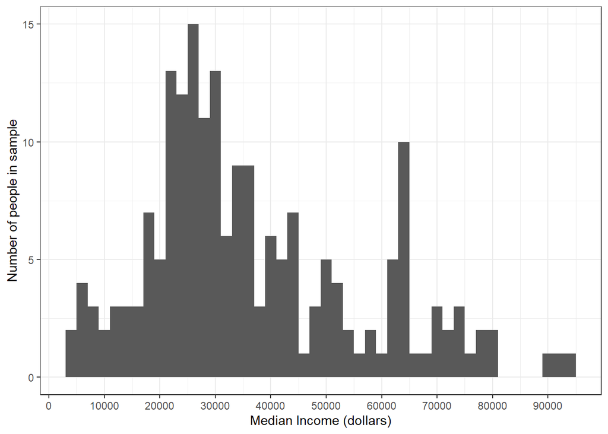

```r
ggplot(tract_data, aes(x = med_incomeE)) +
  geom_histogram(binwidth = 2000) +theme_bw() +scale_x_continuous(name = "Median Income (dollars)",breaks = breaks <- seq(0, 90000, by = 10000),
                     labels = paste(breaks)) + scale_y_continuous(name = "Number of people in sample")
```

The distribution of income resembles a log-normal distribution skewed to the right with a long tail. The median value is less than the mean value. This is a result of some outliers located around and beyond 90,000.

### Percentage of Labour Force Using Public Transportation for Commuting Histogram

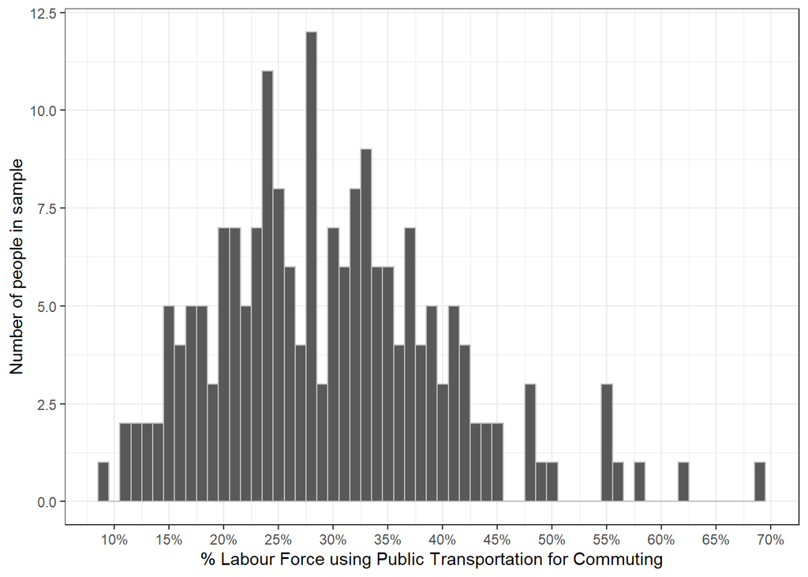

```r
ggplot(tract_data, aes(x = pct_publictrans)) +
  geom_histogram(color = "gray", binwidth = 0.01) +
  theme_bw() +
  scale_x_continuous(name = "% Labour Force using Public Transportation for Commuting",breaks = breaks <- seq(0, 0.70, by = 0.05),
                     labels = paste(breaks*100, "%", sep='')) +
  scale_y_continuous(name = "Number of people in sample")
```

The distribution of percentage of labour force using public transportation has a normal distribution that is also skewed to the right with a long tail. Outliers around 55~70% bring the average of the distribution up, with most of the observations concentrated to the left.

### Avg. Travel Time Histogram

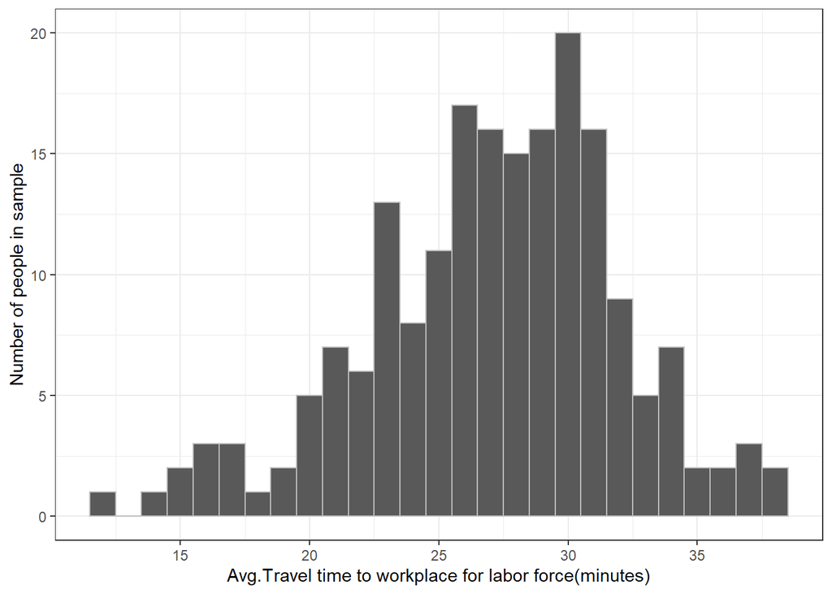

```r
ggplot(tract_data, aes(x = avg_travel_time)) +
  geom_histogram(color = "gray",binwidth = 1) +
  theme_bw() +
  scale_x_continuous(name = "Avg.Travel time to workplace for labor force(minutes)",
                     breaks = breaks <- seq(0, 40, by = 5),
                     labels = paste(breaks)
                     ) +
  scale_y_continuous(name = "Number of people in sample")
```

Data of travel time again resembles a normal distribution but negatively skewed. The mean and median are very close, indicating that there is no significant outliers.

# Distribution of Categorical Variables

## Descriptive statistics

Here I calculate 95-percent confidence interval for the proportion of the population in each category:

```r
black <- t.test (maj_race == "black")
hs_latino <- t.test (maj_race == "hs_latino")
no_majority <- t.test (maj_race == "no_majority")
white <- t.test (maj_race == "white")
asian <- t.test (maj_race == "asian")
```

```r
race_shares <- tibble(`Majority Race` = c("Hispanic/Latino",
                                  "White (not Hispanic/Latino)",
                                  "No Majority",
                                  "Asian (not Hispanic/Latino)",
                                  "Black (not Hispanic/Latino)"),
                 `Sample proportion` = c(paste(prettyNum(hs_latino$estimate*100,
                                                         digits = 3), "%"),
                                         paste(prettyNum(white$estimate*100,
                                                         digits = 3), "%"),
                                         paste(prettyNum(no_majority$estimate*100,
                                                         digits = 3), "%"),
                                         paste(prettyNum(asian$estimate*100,
                                                         digits = 3), "%"),
                                         paste(prettyNum(black$estimate*100,
                                                         digits = 3), "%")),
                 `95-percent confidence interval` = c(
                   paste(prettyNum(hs_latino$conf.int[1]*100, digits=3),
                         "% to ",
                         prettyNum(hs_latino$conf.int[2]*100, digits=3),
                         "%", sep=""),
                   paste(prettyNum(white$conf.int[1]*100, digits=3),
                         "% to ",
                         prettyNum(white$conf.int[2]*100, digits=3),
                         "%", sep=""),
                   paste(prettyNum(no_majority$conf.int[1]*100, digits=3),
                         "% to ",
                         prettyNum(no_majority$conf.int[2]*100, digits=3),
                         "%", sep=""),
                   paste(prettyNum(asian$conf.int[1]*100, digits=3),
                         "% to ",
                         prettyNum(asian$conf.int[2]*100, digits=3),
                         "%", sep=""),
                   paste(prettyNum(black$conf.int[1]*100, digits=3),
                         "% to ",
                         prettyNum(black$conf.int[2]*100, digits=3),
                         "%", sep="")))


knitr::kable(race_shares, caption = "Census tracts in Los Angeles County")
```

| Majority Race | Sample proportion | 95-percent confidence interval |
| --- | --- | --- |
| Hispanic/Latino | 7.25 % | 3.56% to 10.9% |
| White (not Hispanic/Latino) | 50.8 % | 43.7% to 57.9% |
| No Majority | 25.4 % | 19.2% to 31.6% |
| Asian (not Hispanic/Latino) | 0.518 % | -0.504% to 1.54% |
| Black (not Hispanic/Latino) | 16.1 % | 10.8% to 21.3% |

```r
maj_for_born <- t.test(maj_foreign)
maj_nat_born <- t.test(!maj_foreign)
```

```r
for_shares <- tibble(`Majority nativity` = c("Native born","Foreign born"),
                     `Sample proportion` =
                       c(paste(prettyNum(maj_nat_born$estimate*100,
                                         digits = 3), "%"),
                         paste(prettyNum(maj_for_born$estimate*100,
                                         digits = 3), "%")),
                      `95-percent confidence interval` =
                        c(paste(prettyNum(maj_nat_born$conf.int[1]*100,
                                          digits = 3), "% to ",
                                prettyNum(maj_nat_born$conf.int[2]*100,
                                          digits = 3), "%"),
                         paste(prettyNum(maj_for_born$conf.int[1]*100,
                                          digits = 3), "% to ",
                                prettyNum(maj_for_born$conf.int[2]*100,
                                          digits = 3), "%")))
knitr::kable(for_shares, caption = "Census tracts in Los Angeles County")
```

| Majority nativity | Sample proportion | 95-percent confidence interval |
| --- | --- | --- |
| Native born | 94.3 % | 91 % to 97.6 % |
| Foreign born | 5.7 % | 2.4 % to 9 % |